# Assignment pre-series04 - Python

## By Chloé Laignel, Amélie Goubé and Jahinna Duplaix

## 1. Generate a known signal

1. write down the equation of a sinusoid at 1Hz.
2. create a 1D time vector with 1000 samples and a sampling frequency of 100 Hz.
3. using time, create a signal that is a 2D numpy array with the dimensions (x, y, z) over columns : use a sinusoid at 1Hz, with Pi/4 shift from x to y and to z.
4. reproduce the output below (i.e., the text and the 2D and 3D plots)

```python
conda install -c plotly plotly
```

[output not shown]

```
t.shape = (100, 1)
S.shape = (100, 3)
phase_shift = 0.7853981633974483
```

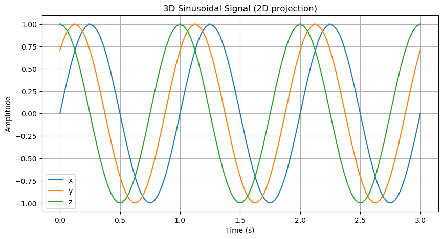

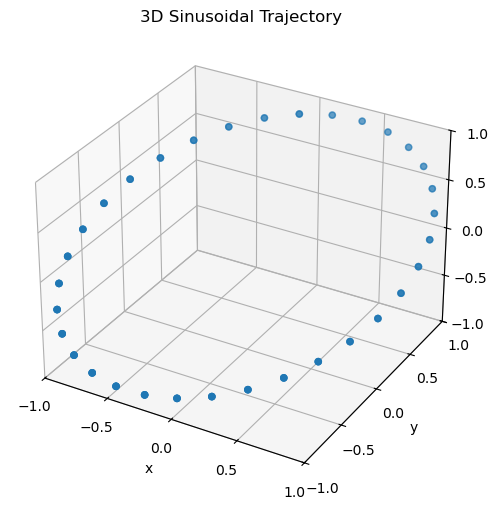

```python
import numpy as np
import matplotlib.pyplot as plt
import plotly.graph_objects as go

# -----------------------------------------
# Question 1 – Generate a known signal
# -----------------------------------------

# Sampling parameters
fs = 100              # sampling frequency (Hz)
f0 = 1.0              # signal frequency (Hz)
A = 1.0               # amplitude

# Phase shift between axes
phase_shift = 0.25 * np.pi   # 0.25π rad = 45 degrees

# Create a time vector from 0 to 3 seconds with exactly 100 samples
t = np.linspace(0, 3, 100).reshape(-1, 1)

# Build a 3D signal:
# x(t): phase = 0
# y(t): phase shifted by +phase_shift
# z(t): phase shifted by +2*phase_shift
s_x = A * np.sin(2 * np.pi * f0 * t + 0)
s_y = A * np.sin(2 * np.pi * f0 * t + phase_shift)
s_z = A * np.sin(2 * np.pi * f0 * t + 2 * phase_shift)

# Stack the components into one array (N, 3)
S = np.hstack([s_x, s_y, s_z])

# Print shapes (as requested in the assignment)
print("t.shape =", t.shape)
print("S.shape =", S.shape)
print("phase_shift =", phase_shift)

# -----------------------------------------
# 2D Plot (x, y, z over time)
# -----------------------------------------
plt.figure(figsize=(10, 5))
plt.plot(t, S[:,0], label='x')
plt.plot(t, S[:,1], label='y')
plt.plot(t, S[:,2], label='z')
plt.title("3D Sinusoidal Signal (2D projection)")
plt.xlabel("Time (s)")
plt.ylabel("Amplitude")
plt.legend()
plt.grid()
plt.show()

# -----------------------------------------
# 3D Plot (x, y, z trajectory)
# -----------------------------------------
from mpl_toolkits.mplot3d import Axes3D

fig = plt.figure(figsize=(8, 6))
ax = fig.add_subplot(111, projection='3d')

ax.scatter(S[:,0], S[:,1], S[:,2])
ax.set_title("3D Sinusoidal Trajectory")
ax.set_xlabel("x")
ax.set_ylabel("y")
ax.set_zlabel("z")

# limits of the axes
ax.set_xlim(-1, 1)
ax.set_ylim(-1, 1)
ax.set_zlim(-1, 1)

ax.set_xticks(np.arange(-1, 1.5, 0.5))
ax.set_yticks(np.arange(-1, 1.5, 0.5))
ax.set_zticks(np.arange(-1, 1.5, 0.5))

plt.show()
```

## 2. Estimate the derivative of the signal

1. write down the math to get the derivative of a sine wave.

Given a sine function: $$ s(t) = A \sin(2 \pi f t + \phi) $$

Its analytical derivative is:

$$ \frac{ds}{dt} = 2 \pi f A \cos(2 \pi f t + \phi) $$

2. write down the equation of the derivative of signal along each axis.

For a 3D signal:

$$ \mathbf{S}(t) = \begin{bmatrix} x(t) \\ y(t) \\ z(t) \end{bmatrix} $$

Each component is a sinusoid with a phase shift:

$$ \dot{x}(t) = 2 \pi f A \cos(2 \pi f t + \phi_x) $$

$$ \dot{y}(t) = 2 \pi f A \cos(2 \pi f t + \phi_y) $$

$$ \dot{z}(t) = 2 \pi f A \cos(2 \pi f t + \phi_z) $$

3. create a function that estimates the time derivative of a signal:

We can estimate the derivative numerically using two methods:

**1. Forward difference:**

$$ \dot{s}(t_i) \approx \frac{s(t_{i+1}) - s(t_i)}{t_{i+1} - t_i} $$

**2. Central difference:**

$$ \dot{s}(t_i) \approx \frac{s(t_{i+1}) - s(t_{i-1})}{t_{i+1} - t_{i-1}} $$

> Note: At the boundaries, forward/backward difference is used to keep the same array length.

```python
# ---------------------------------------------------------
# Derivative estimation functions (Forward and Central)
# ---------------------------------------------------------

def derivative_forward(signal, time):
    """
    Estimate the derivative using the forward difference method.
    Maintains the same length as the input signal by using
    a backward difference for the last sample.
    """
    s = np.asarray(signal)
    t = np.asarray(time).reshape(-1)

    if s.ndim == 1:
        s = s.reshape(-1, 1)  # convert to 2D

    N, D = s.shape
    ds = np.zeros((N, D))

    # Forward difference for all points except the last
    dt = np.diff(t)
    ds[:-1, :] = (s[1:, :] - s[:-1, :]) / dt[:, None]

    # Backward difference at the final point
    ds[-1, :] = (s[-1, :] - s[-2, :]) / (t[-1] - t[-2])

    return ds


def derivative_central(signal, time):
    """
    Estimate the derivative using the central difference method.
    Uses forward/backward difference at the boundaries.
    """
    s = np.asarray(signal)
    t = np.asarray(time).reshape(-1)

    if s.ndim == 1:
        s = s.reshape(-1, 1)

    N, D = s.shape
    ds = np.zeros((N, D))

    # Central difference for interior points
    for i in range(1, N - 1):
        dt = t[i + 1] - t[i - 1]
        ds[i, :] = (s[i + 1, :] - s[i - 1, :]) / dt

    # Forward and backward differences at the boundaries
    ds[0, :] = (s[1, :] - s[0, :]) / (t[1] - t[0])
    ds[-1, :] = (s[-1, :] - s[-2, :]) / (t[-1] - t[-2])

    return ds
```

4. apply the function to the signal and plot the result.

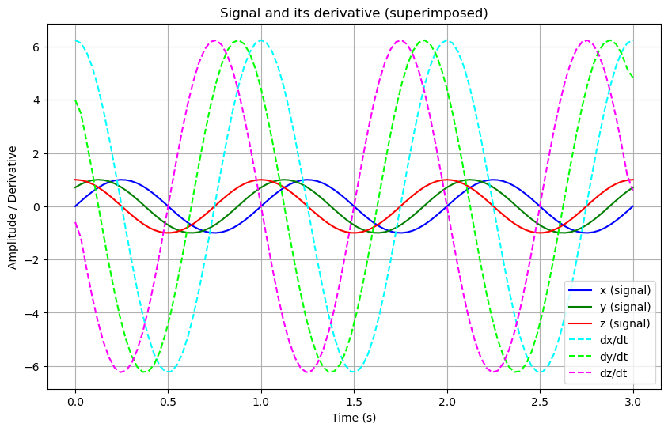

```python
# Compute derivatives if not already done
dS_central = derivative_central(S, t)  # central difference

# Plot original signal + derivative on the same figure
plt.figure(figsize=(10,6))

# Plot original signal (x, y, z)
plt.plot(t, S[:,0], label='x (signal)', color='blue')
plt.plot(t, S[:,1], label='y (signal)', color='green')
plt.plot(t, S[:,2], label='z (signal)', color='red')

# Plot derivative of the signal (x, y, z)
plt.plot(t, dS_central[:,0], '--', label='dx/dt', color='cyan')
plt.plot(t, dS_central[:,1], '--', label='dy/dt', color='lime')
plt.plot(t, dS_central[:,2], '--', label='dz/dt', color='magenta')

# Labels and title
plt.xlabel("Time (s)")
plt.ylabel("Amplitude / Derivative")
plt.title("Signal and its derivative (superimposed)")
plt.legend()
plt.grid()
plt.show()
```

## 3. Estimate the tangential velocity of the signal

3.1 Definition

The **tangential velocity** is the magnitude of the instantaneous rate of change of the position vector.  
In other words, it is the Euclidean norm of the derivative of the signal vector:

$$ v_\text{tan}(t) = \|\dot{\mathbf{S}}(t)\|_2 = \sqrt{\dot{x}^2(t) + \dot{y}^2(t) + \dot{z}^2(t)} $$

3.2 Formula using linear algebra

Let the signal be a matrix:

$$ S \in \mathbb{R}^{N \times d} $$

with **N samples** and **d dimensions**.  
The derivative is:

$$ \dot{S} \in \mathbb{R}^{N \times d} $$

Then the tangential velocity vector is:

$$ v = \text{norm}(\dot{S}, \text{axis}=1) \in \mathbb{R}^N $$

3.3 Python function to compute tangential velocity

```python
def tangential_velocity(signal, time, derivative_method='central'):
    """
    Compute the tangential velocity of a signal and return it as a 2D numpy array.

    Parameters:
        signal: ndarray of shape (N, d)
        time: ndarray of shape (N,) or (N,1)
        derivative_method: 'central' or 'forward'

    Returns:
        v: ndarray of shape (N, 1) containing the tangential velocity
    """
    s = np.asarray(signal)

    # Compute derivative
    if derivative_method == 'central':
        ds = derivative_central(s, time)
    elif derivative_method == 'forward':
        ds = derivative_forward(s, time)
    else:
        raise ValueError("derivative_method must be 'central' or 'forward'")

    # Tangential velocity = L2 norm of derivative along each row
    v = np.linalg.norm(ds, axis=1)

    # Return as 2D column array
    return v.reshape(-1, 1)
```

3.4 Test the function

```
1D test: s1.shape = (100,) v1.shape = (100, 1)
2D test: s2.shape = (100, 2) v2.shape = (100, 1)
3D test: S.shape = (100, 3) v3.shape = (100, 1)
```

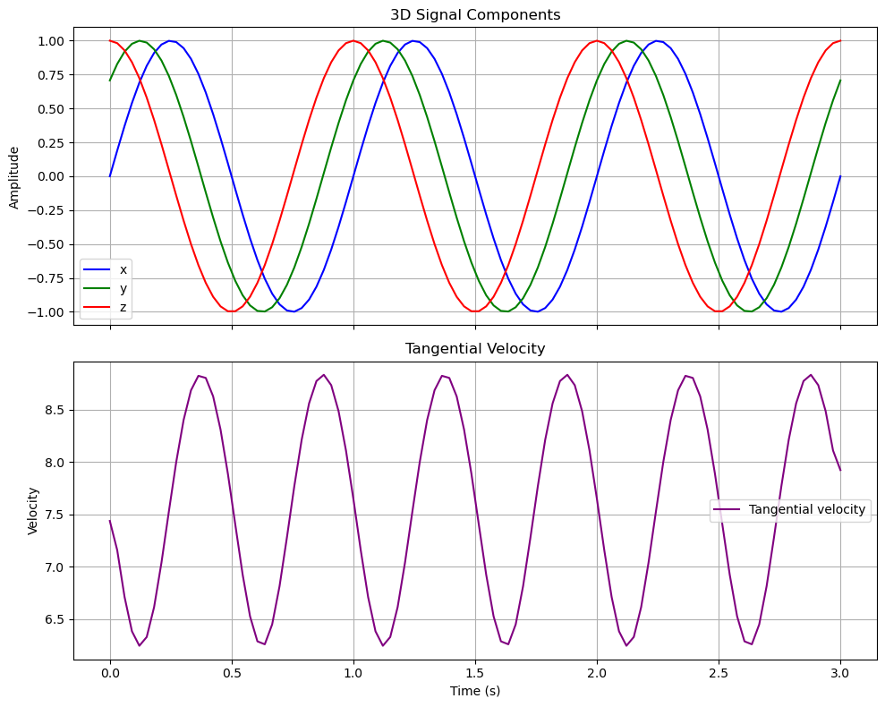

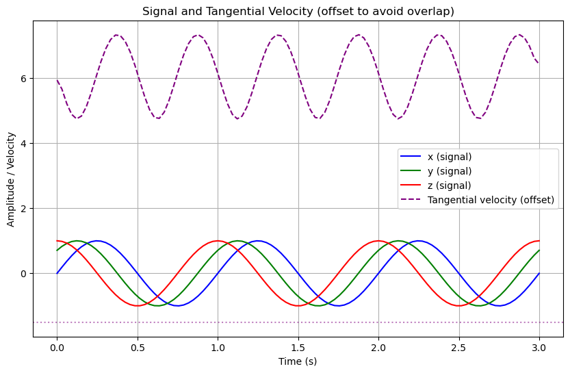

```python
# 1D signal
s1 = (np.sin(2*np.pi*1*t)).reshape(-1)
v1 = tangential_velocity(s1, t)
print("1D test: s1.shape =", s1.shape, "v1.shape =", v1.shape)

# 2D signal
s2 = np.hstack([s_x, s_y])
v2 = tangential_velocity(s2, t)
print("2D test: s2.shape =", s2.shape, "v2.shape =", v2.shape)

# 3D signal (already S)
v3 = tangential_velocity(S, t)
print("3D test: S.shape =", S.shape, "v3.shape =", v3.shape)

# Plot tangential velocity

# Compute tangential velocity if not already done
v3 = tangential_velocity(S, t)

# Create figure with 2 subplots (stacked vertically)
fig, axs = plt.subplots(2, 1, figsize=(10, 8), sharex=True)

# --------------------------
# Top subplot: original signal
# --------------------------
axs[0].plot(t, S[:,0], label='x', color='blue')
axs[0].plot(t, S[:,1], label='y', color='green')
axs[0].plot(t, S[:,2], label='z', color='red')
axs[0].set_ylabel("Amplitude")
axs[0].set_title("3D Signal Components")
axs[0].legend()
axs[0].grid()

# --------------------------
# Bottom subplot: tangential velocity
# --------------------------
axs[1].plot(t, v3, label='Tangential velocity', color='purple')
axs[1].set_xlabel("Time (s)")
axs[1].set_ylabel("Velocity")
axs[1].set_title("Tangential Velocity")
axs[1].legend()
axs[1].grid()

# --------------------------
# Adjust layout and show
# --------------------------
plt.tight_layout()
plt.show()

# Offset the tangential velocity to display it below the signal
offset = -1.5                  # vertical offset (adjust if needed)
v3_offset = v3.flatten() + offset  # flatten in case v3 is (N,1)

plt.figure(figsize=(10,6))


# --------------------------
# Plot the original signal (x, y, z)
# --------------------------
plt.plot(t, S[:,0], label='x (signal)', color='blue')
plt.plot(t, S[:,1], label='y (signal)', color='green')
plt.plot(t, S[:,2], label='z (signal)', color='red')

# --------------------------
# Plot the tangential velocity (offset)
# --------------------------
plt.plot(t, v3_offset, '--', label='Tangential velocity (offset)', color='purple')

# Add a horizontal reference line to indicate zero level of velocity
plt.axhline(offset, color='purple', linestyle=':', alpha=0.5)

# Labels, title, grid and legend
plt.xlabel("Time (s)")
plt.ylabel("Amplitude / Velocity")
plt.title("Signal and Tangential Velocity (offset to avoid overlap)")
plt.legend()
plt.grid()
plt.show()
```

## 4. Create an interactive plot with the plotly library

```python
import plotly.graph_objects as go
from plotly.offline import plot
import plotly.io as pio
import numpy as np

pio.renderers.default = 'iframe'
# Assume S, v3, t are already defined

# Flatten v3 in case it is (N,1)
v3_flat = v3.flatten()

# Create figure
fig = go.Figure()

# Add traces for the signal
fig.add_trace(go.Scatter(x=t.flatten(), y=S[:,0], mode='lines', name='x (signal)'))
fig.add_trace(go.Scatter(x=t.flatten(), y=S[:,1], mode='lines', name='y (signal)'))
fig.add_trace(go.Scatter(x=t.flatten(), y=S[:,2], mode='lines', name='z (signal)'))

# Add trace for tangential velocity (dashed line)
fig.add_trace(go.Scatter(x=t.flatten(), y=v3_flat, mode='lines', name='Tangential velocity',
                         line=dict(dash='dash', color='purple')))

# Update layout
fig.update_layout(
    title="Signal and Tangential Velocity (Interactive)",
    xaxis_title="Time (s)",
    yaxis_title="Amplitude / Velocity",
    legend_title="Legend",
    hovermode="x unified"
)

# Show interactive plot
fig.show()

# Export to HTML
fig.write_html("signal_and_velocity.html")

from IPython.display import HTML

HTML('<a href="signal_and_velocity.html" target="_blank">🔗 Open interactive plot</a>')
```

[interactive chart not shown]

🔗 Open interactive plot